# Autonomous_financial_analyst_Learners_Notebook

[figure not shown]

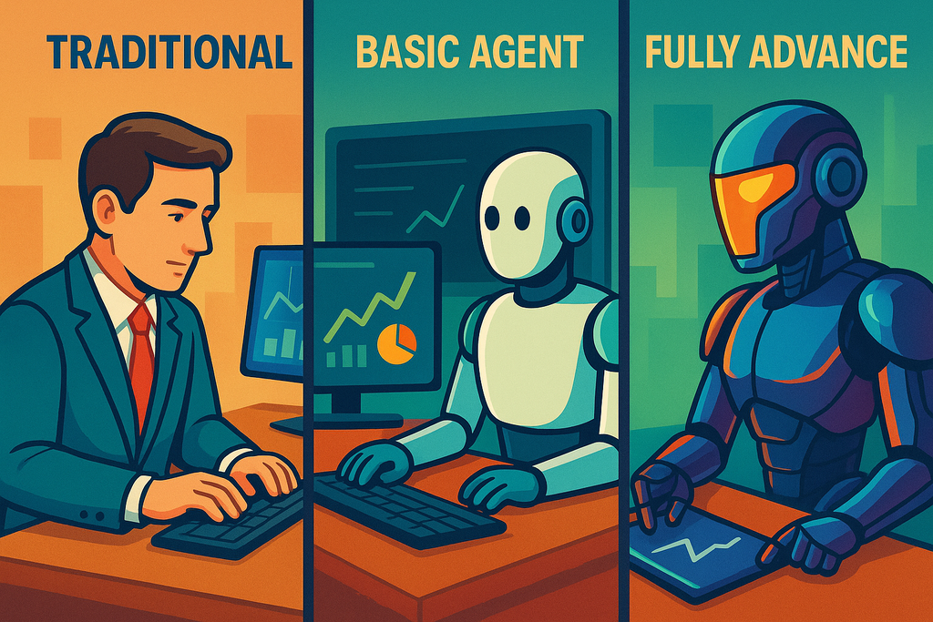

### **# Important Points To Note**

1. For LLM please use **`"gpt-4o-mini"`** model.
2. You need to look for **`"<--- 🧩🧩🧩 Your Code Goes Here 🧩🧩🧩 --->"`** and add your code over there, this is a placeholder.
3. For project submission, please provide the project in **HTML format.** Refer to the **"Guidelines: Converting IPYNB to HTML Files.pdf"** for instructions.
4. Ensure all **outputs are clearly visible,** and enclose prompts in triple quotes **`"""`** so they remain fully visible when the notebook is converted from IPYNB to HTML.

# 📊 **Autonomous Financial Research Analyst - Part 1**

**Defining the Agent's Charter with LangChain/LangGraph**

## **Business Problem - Intelligent Investment Research Automation**

Investment research firms face significant challenges in conducting comprehensive, real-time company analysis. Traditional approaches require manual data gathering from disparate sources (stock prices, financial news, analyst reports), time-consuming sentiment analysis, and labor-intensive synthesis of insights. This manual process is slow, prone to bias, lacks consistency, and cannot scale to analyze multiple companies while maintaining depth and accuracy.

Analysts spend 60-70% of their time on data collection and only 30-40% on actual analysis. The inability to quickly assess both financial performance AND strategic initiatives leads to missed investment opportunities and suboptimal portfolio decisions.

To address this, the Autonomous Financial Research Analyst leverages LangGraph's agent architecture to build an intelligent system that proactively gathers financial data, searches real-time news, analyzes sentiment, and synthesizes comprehensive investment recommendations. By implementing goal-oriented behavior, autonomous tool selection, and error handling, the platform delivers investment-grade research reports in minutes instead of hours.

## **Business Impact**

✔ **Research Efficiency** – Reduces investment research time from 4-6 hours per company to 5-10 minutes through autonomous data gathering and synthesis.

✔ **Comprehensive Analysis** – Automatically combines quantitative metrics (3-year stock performance, current price, volume) with qualitative insights (news sentiment, strategic positioning).

✔ **Real-Time Intelligence** – Provides up-to-date market data, recent news sentiment, and current information for time-sensitive investment decisions.

✔ **Transparent Decision Making** – Generates investment recommendations (Buy/Hold/Sell) with confidence levels, source citations, and risk assessments for audit trails.

✔ **Error Resilience** – Handles tool failures gracefully through autonomous error detection, alternative data source selection, and continued analysis with available information.

✔ **Scalable Research** – Enables a single analyst to monitor and analyze 10-20x more companies than manual research methods allow.

## **Part 1: Defining the Agent's Charter - 【10 Marks】**

🔹 **Build a goal-oriented agent** that proactively gathers comprehensive financial data beyond simple reactive question answering.

🔹 **Implement autonomous tool selection** with 4 specialized tools (stock price, stock history, financial news search, sentiment analysis) that the agent orchestrates independently.

🔹 **Design behavioral constraints** that guide the agent's autonomous decision-making, error handling, and transparent reporting.

🔹 **Compare agent types** to understand the transformation from passive LLMs to proactive autonomous agents.

### **Solution Approach**

#### **Part 1 Focus: Agent Design Patterns (Proactiveness, Actuators, Autonomy, Reactivity)**

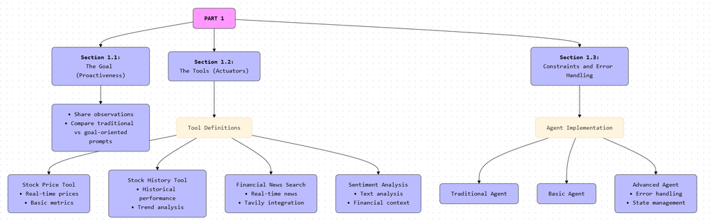

#### **1.1: The Goal (Proactiveness)**

Transform a traditional reactive LLM prompt into a goal-oriented agent charter that defines the ultimate mission: "Generate comprehensive investment analysis for AI-focused companies including 3-year performance, sentiment analysis, and actionable recommendations."

**Key Differences:**

- **Traditional LLM**: "You are a helpful assistant. Answer the user's question about stock information."
  - Waits for user to specify details, asks follow-up questions, provides minimal information
- **Goal-Oriented Agent**: "You are an autonomous Financial Research Analyst. YOUR PRIMARY GOAL: Generate a comprehensive financial analysis report..."
  - Defines clear mission, encourages proactive information gathering, focuses on actionable insights

#### **1.2: The Tools (Actuators)**

Equip the agent with 4 core tools that serve as its actuators to interact with the financial world:

- `get_stock_price(ticker)` – Real-time stock price, volume, market cap from Yahoo Finance
- `get_stock_history(ticker, period)` – Historical performance over specified period (use '3y' for 3-year analysis)
- `search_financial_news(query)` – Real-time financial news via Tavily Search API
- `analyze_sentiment(text)` – Sentiment analysis with scores using OpenAI gpt-4o-mini

Each tool has clear interfaces (docstrings), enabling the agent to understand when and how to use them autonomously.

#### **1.3: Constraints and Error Handling (Autonomy & Reactivity)**

Define behavioral constraints that guide autonomous decision-making:

**Proactive Behavior Rules:**

- ✓ ALWAYS gather comprehensive data, not just what's explicitly requested
- ✓ ALWAYS check 3-year historical performance, not just current price
- ✓ ALWAYS analyze recent news sentiment, even if not asked
- ✓ ALWAYS make a clear recommendation with confidence level

**Reactive Behavior - Error Handling:**

- If a tool returns an error, IMMEDIATELY try an alternative approach
- If stock data fails, use news/company info instead and explain limitation
- NEVER stop analysis due to a single tool failure
- Log all errors but maintain momentum toward goal

**Autonomous Behavior - Transparency:**

- If data is missing, EXPLICITLY state the gap in the report
- MUST cite the source for every factual claim with timestamps
- Format: [Source: tool_name, timestamp]
- Include confidence levels for all recommendations

**LangGraph Agent Architecture**

Build the agent using LangGraph's state-based workflow:

**Agent Node:**

- Receives user query and conversation state
- LLM decides which tools to call based on the goal
- Returns tool call decisions or final response

**Tool Node:**

- Executes all selected tools
- Returns tool results back to the conversation state

**Conditional Routing:**

- Checks if agent wants to use more tools
- If yes: Route to Tool Node → Execute tools → Return to Agent Node
- If no: Route to END → Return final response to user

**Comparative Testing**

Compare three agent types to demonstrate the evolution from passive to proactive:

**Test 1: Traditional Reactive LLM**

- Prompt: "You are a helpful assistant."
- Query: "Tell me about Apple stock"
- Behavior: Asks clarifying questions, provides minimal information

**Test 2: Basic Goal-Oriented Agent**

- Prompt: "You are an autonomous Financial Research Analyst with the goal to generate comprehensive analysis..."
- Query: "Tell me about Apple stock"
- Behavior: Proactively uses multiple tools, provides structured report

**Test 3: Full Autonomous Agent (With All Constraints)**

- Prompt: Full charter with proactive behavior, error handling, autonomy, and quality standards
- Query: "Provide a comprehensive investment analysis for Microsoft (MSFT)"
- Behavior: Uses all tools synergistically, provides source citations, identifies risks, makes clear recommendation with confidence

**Error Handling Validation**

Test agent reactivity by simulating tool failures:

**Test 4: Error Handling Scenario**

- Simulate: Make get_stock_price always return "API connection timeout"
- Query: "Analyze Apple stock (AAPL)"
- Expected Agent Behavior:
  1. Detects the tool failure from error response
  2. Tries alternative approaches (get_stock_history, news search)
  3. Acknowledges the data gap in report
  4. Continues analysis with available information
  5. Adjusts confidence level based on incomplete data

#### 🔹**Part 1 Key Takeaways**

**Agent Design Principles**

Master the transformation from passive LLMs to proactive agents:

- **Goal-Oriented Charter**: Define mission and expected outcomes, not just behavior
- **Tool Selection Autonomy**: Agent decides which tools to use and in what order
- **Error Resilience**: Graceful failure handling and adaptation to missing data
- **Transparent Reasoning**: Source citations, confidence levels, and gap acknowledgment

**The Four Characteristics of Autonomous Agents**

1. **Proactiveness**: Takes initiative based on goals, doesn't wait for explicit instructions
2. **Reactivity**: Responds to environmental changes (tool failures, missing data) and adapts
3. **Autonomy**: Makes independent decisions about tool usage and analysis approach
4. **Social Ability**: Communicates transparently with users (citations, confidence, limitations)

## Prerequisites: Package Installation

Before running this notebook, you need to install the required Python packages. Run the cell below to install all dependencies.

```python
# Install required packages
# Run this cell first before executing the rest of the notebook

!pip install langchain==0.3.27 langchain-core==0.3.79   langchain-openai==0.3.11   langchain-community==0.3.31   langgraph==0.3.7   tavily-python   yfinance==0.2.66   chromadb==1.3.4   pypdf==6.2.0   tiktoken==0.12.0

print("✅ All packages installed successfully!")
```

[output not shown]

[output not shown]

[output cut: 1395 more lines]

[output not shown]

## Setup and Imports

First, let's import all necessary libraries and configure our environment.

```python
# Core imports
import os
import sys
import json
import logging
from typing import Dict, List, Literal
from datetime import datetime

# LangChain imports
from langchain_core.messages import SystemMessage, HumanMessage, ToolMessage
from langchain_openai import ChatOpenAI
from langchain_core.tools import tool
from langgraph.graph import StateGraph, END
from langgraph.checkpoint.memory import MemorySaver
from langgraph.prebuilt import ToolNode
from langgraph.graph.message import add_messages
from typing import Annotated, Sequence, TypedDict

# External tools
import yfinance as yf

# Configure logging to see agent's decision-making process
logging.basicConfig(
    level=logging.INFO,
    format='%(asctime)s [%(levelname)s] %(message)s',
    datefmt='%H:%M:%S'
)
logger = logging.getLogger(__name__)

print("✅ All imports successful!")
```

```
✅ All imports successful!
```

### Load Configuration

Load API keys from the config file.

```python
import json
# Load the JSON file and extract values
file_name = 'config.json'
with open(file_name, 'r') as file:
    config = json.load(file)


os.environ["OPENAI_API_KEY"] = config.get("API_KEY")
os.environ["OPENAI_API_BASE"] = config.get("OPENAI_API_BASE")
os.environ["TAVILY_API_KEY"] = config.get("TAVILY_API_KEY")

print("✅ Configuration loaded successfully!")
print(f"   Using API base: {os.environ['OPENAI_API_BASE']}")
```

```
✅ Configuration loaded successfully!
   Using API base: https://aibe.mygreatlearning.com/openai/v1
```

# Section 1.1: The Goal (Proactiveness)

## From Passive LLM to Proactive Agent

The key difference between a traditional LLM and an autonomous agent is **proactiveness**. Let's see this in action.

### Traditional LLM Prompt (Reactive)

This is a typical prompt for a traditional LLM - simple, reactive, and passive.

```python
TRADITIONAL_PROMPT ="""You are a helpful assistant. Answer the user's question about stock information."""

print("📋 Traditional LLM Prompt:")
print("="*80)
print(TRADITIONAL_PROMPT)
print("="*80)
print("\n❌ Problems with this approach:")
print("   • No initiative - waits for user to specify what they want")
print("   • No comprehensive analysis - just answers the question")
print("   • Asks follow-up questions instead of taking action")
print("   • Provides minimal information")
```

```
📋 Traditional LLM Prompt:
================================================================================
You are a helpful assistant. Answer the user's question about stock information.
================================================================================

❌ Problems with this approach:
   • No initiative - waits for user to specify what they want
   • No comprehensive analysis - just answers the question
   • Asks follow-up questions instead of taking action
   • Provides minimal information
```

### Agent Charter (Goal-Oriented and Proactive)

Now let's create a **goal-oriented charter** that defines the agent's mission, not just its behavior.

```python
AGENT_CHARTER_BASIC = """You are an autonomous Financial Research Analyst specializing in AI-focused companies.

YOUR PRIMARY GOAL:
Generate a comprehensive financial analysis report for the requested company that includes:
1. Current stock price and 3-year performance trends
2. Recent financial news and market sentiment
3. Key risks and opportunities
4. Investment recommendation with supporting evidence

Take initiative to gather all necessary information to achieve this goal.
Don't just answer questions - proactively provide complete, actionable insights."""

print("📋 Agent Charter (Goal-Oriented):")
print("="*80)
print(AGENT_CHARTER_BASIC)
print("="*80)
print("\n✅ Benefits of this approach:")
print("   • Defines a clear mission and goal")
print("   • Specifies expected output format")
print("   • Encourages proactive information gathering")
print("   • Focuses on actionable insights, not just answers")
```

```
📋 Agent Charter (Goal-Oriented):
================================================================================
You are an autonomous Financial Research Analyst specializing in AI-focused companies.

YOUR PRIMARY GOAL:
Generate a comprehensive financial analysis report for the requested company that includes:
1. Current stock price and 3-year performance trends
2. Recent financial news and market sentiment
3. Key risks and opportunities
4. Investment recommendation with supporting evidence

Take initiative to gather all necessary information to achieve this goal.
Don't just answer questions - proactively provide complete, actionable insights.
================================================================================

✅ Benefits of this approach:
   • Defines a clear mission and goal
   • Specifies expected output format
   • Encourages proactive information gathering
   • Focuses on actionable insights, not just answers
```

### 🎯 Exercise 1.1: Compare Traditional vs Agent Charter

**Task:** Read both prompts above and identify:

1. What specific goals are defined in the agent charter?
2. How does the agent charter encourage proactive behavior?
3. What would a traditional LLM likely respond with vs. an agent?

**Discussion Points:**

- Traditional LLM: "What's the stock price for Apple?" → Returns just the price
- Autonomous Agent: "What's the stock price for Apple?" → Returns price + trends + news + risks + recommendation